# HeartDisease

**PRCP-1016 - HEART DISEASE PREDICTION**

**1. Project Overview & Environment Setup**

**1.1 Project Objective**

The primary objective of this project is to predict the likelihood of Cardiovascular Disease (CVD) and to develop an accurate, high-sensitivity Machine Learning model based on patient clinical indicators.

By identifying high-risk individuals early, healthcare institutions can transition from reactive treatment to proactive prevention, ultimately minimizing life-threatening complications like cardiac arrests and strokes.

This project includes:

1. Data Analysis
2. Predictive Modeling
3. Model Comparison
4. Suggestions for prevention of life threatening heart disease.

**1.2 Library Installations & Imports**

```python
# Import core data science libraries
import numpy as np
import pandas as pd
import seaborn as sns
import matplotlib.pyplot as plt
import warnings
warnings.filterwarnings('ignore')
```

```python
pwd
```

```
'C:\\Users\\Brinda\\HeartDisease\\Data'
```

**1.3 Data Loading**

```python
# Extracting the data directly from the cloudfront link
train_values = pd.read_csv("values.csv")
train_labels = pd.read_csv("labels.csv")
```

```python
train_values.head()
```

|  | patient_id | slope_of_peak_exercise_st_segment | thal | resting_blood_pressure | chest_pain_type | num_major_vessels | fasting_blood_sugar_gt_120_mg_per_dl | resting_ekg_results | serum_cholesterol_mg_per_dl | oldpeak_eq_st_depression | sex | age | max_heart_rate_achieved | exercise_induced_angina |
| --- | --- | --- | --- | --- | --- | --- | --- | --- | --- | --- | --- | --- | --- | --- |
| 0 | 0z64un | 1 | normal | 128 | 2 | 0 | 0 | 2 | 308 | 0.0 | 1 | 45 | 170 | 0 |
| 1 | ryoo3j | 2 | normal | 110 | 3 | 0 | 0 | 0 | 214 | 1.6 | 0 | 54 | 158 | 0 |
| 2 | yt1s1x | 1 | normal | 125 | 4 | 3 | 0 | 2 | 304 | 0.0 | 1 | 77 | 162 | 1 |
| 3 | l2xjde | 1 | reversible_defect | 152 | 4 | 0 | 0 | 0 | 223 | 0.0 | 1 | 40 | 181 | 0 |
| 4 | oyt4ek | 3 | reversible_defect | 178 | 1 | 0 | 0 | 2 | 270 | 4.2 | 1 | 59 | 145 | 0 |

```python
train_labels.head()
```

|  | patient_id | heart_disease_present |
| --- | --- | --- |
| 0 | 0z64un | 0 |
| 1 | ryoo3j | 0 |
| 2 | yt1s1x | 1 |
| 3 | l2xjde | 1 |
| 4 | oyt4ek | 0 |

```python
# Merge values and labels
data = pd.merge(train_values, train_labels, on='patient_id')
```

```python
# Copy of dataset
data1 = data.copy()
```

```python
# Data inspection
data.head()
```

|  | patient_id | slope_of_peak_exercise_st_segment | thal | resting_blood_pressure | chest_pain_type | num_major_vessels | fasting_blood_sugar_gt_120_mg_per_dl | resting_ekg_results | serum_cholesterol_mg_per_dl | oldpeak_eq_st_depression | sex | age | max_heart_rate_achieved | exercise_induced_angina | heart_disease_present |
| --- | --- | --- | --- | --- | --- | --- | --- | --- | --- | --- | --- | --- | --- | --- | --- |
| 0 | 0z64un | 1 | normal | 128 | 2 | 0 | 0 | 2 | 308 | 0.0 | 1 | 45 | 170 | 0 | 0 |
| 1 | ryoo3j | 2 | normal | 110 | 3 | 0 | 0 | 0 | 214 | 1.6 | 0 | 54 | 158 | 0 | 0 |
| 2 | yt1s1x | 1 | normal | 125 | 4 | 3 | 0 | 2 | 304 | 0.0 | 1 | 77 | 162 | 1 | 1 |
| 3 | l2xjde | 1 | reversible_defect | 152 | 4 | 0 | 0 | 0 | 223 | 0.0 | 1 | 40 | 181 | 0 | 1 |
| 4 | oyt4ek | 3 | reversible_defect | 178 | 1 | 0 | 0 | 2 | 270 | 4.2 | 1 | 59 | 145 | 0 | 0 |

**2. Basic Checks and Observations**

**2.1 Basic Checks**

```python
data1.shape
```

```
(180, 15)
```

```python
data1.columns
```

```
Index(['patient_id', 'slope_of_peak_exercise_st_segment', 'thal',
       'resting_blood_pressure', 'chest_pain_type', 'num_major_vessels',
       'fasting_blood_sugar_gt_120_mg_per_dl', 'resting_ekg_results',
       'serum_cholesterol_mg_per_dl', 'oldpeak_eq_st_depression', 'sex', 'age',
       'max_heart_rate_achieved', 'exercise_induced_angina',
       'heart_disease_present'],
      dtype='object')
```

```python
data1.info()
```

```
<class 'pandas.core.frame.DataFrame'>
RangeIndex: 180 entries, 0 to 179
Data columns (total 15 columns):
 #   Column                                Non-Null Count  Dtype
---  ------                                --------------  -----
 0   patient_id                            180 non-null    object
 1   slope_of_peak_exercise_st_segment     180 non-null    int64
 2   thal                                  180 non-null    object
 3   resting_blood_pressure                180 non-null    int64
 4   chest_pain_type                       180 non-null    int64
 5   num_major_vessels                     180 non-null    int64
 6   fasting_blood_sugar_gt_120_mg_per_dl  180 non-null    int64
 7   resting_ekg_results                   180 non-null    int64
 8   serum_cholesterol_mg_per_dl           180 non-null    int64
 9   oldpeak_eq_st_depression              180 non-null    float64
 10  sex                                   180 non-null    int64
 11  age                                   180 non-null    int64
 12  max_heart_rate_achieved               180 non-null    int64
 13  exercise_induced_angina               180 non-null    int64
 14  heart_disease_present                 180 non-null    int64
dtypes: float64(1), int64(12), object(2)
memory usage: 21.2+ KB
```

```python
data1.describe()
```

|  | slope_of_peak_exercise_st_segment | resting_blood_pressure | chest_pain_type | num_major_vessels | fasting_blood_sugar_gt_120_mg_per_dl | resting_ekg_results | serum_cholesterol_mg_per_dl | oldpeak_eq_st_depression | sex | age | max_heart_rate_achieved | exercise_induced_angina | heart_disease_present |
| --- | --- | --- | --- | --- | --- | --- | --- | --- | --- | --- | --- | --- | --- |
| count | 180.000000 | 180.000000 | 180.000000 | 180.000000 | 180.000000 | 180.000000 | 180.000000 | 180.000000 | 180.000000 | 180.000000 | 180.000000 | 180.000000 | 180.000000 |
| mean | 1.550000 | 131.311111 | 3.155556 | 0.694444 | 0.161111 | 1.050000 | 249.211111 | 1.010000 | 0.688889 | 54.811111 | 149.483333 | 0.316667 | 0.444444 |
| std | 0.618838 | 17.010443 | 0.938454 | 0.969347 | 0.368659 | 0.998742 | 52.717969 | 1.121357 | 0.464239 | 9.334737 | 22.063513 | 0.466474 | 0.498290 |
| min | 1.000000 | 94.000000 | 1.000000 | 0.000000 | 0.000000 | 0.000000 | 126.000000 | 0.000000 | 0.000000 | 29.000000 | 96.000000 | 0.000000 | 0.000000 |
| 25% | 1.000000 | 120.000000 | 3.000000 | 0.000000 | 0.000000 | 0.000000 | 213.750000 | 0.000000 | 0.000000 | 48.000000 | 132.000000 | 0.000000 | 0.000000 |
| 50% | 1.000000 | 130.000000 | 3.000000 | 0.000000 | 0.000000 | 2.000000 | 245.500000 | 0.800000 | 1.000000 | 55.000000 | 152.000000 | 0.000000 | 0.000000 |
| 75% | 2.000000 | 140.000000 | 4.000000 | 1.000000 | 0.000000 | 2.000000 | 281.250000 | 1.600000 | 1.000000 | 62.000000 | 166.250000 | 1.000000 | 1.000000 |
| max | 3.000000 | 180.000000 | 4.000000 | 3.000000 | 1.000000 | 2.000000 | 564.000000 | 6.200000 | 1.000000 | 77.000000 | 202.000000 | 1.000000 | 1.000000 |

**2.2 Observations**

The dataset contains a mix of numerical (e.g., blood pressure) and categorical/discrete variables (represented numerically, like chest pain type and fasting blood sugar).

The dataset contains no null values and represents a patient population where nearly 1 in 6 individuals show elevated fasting blood sugar, and there is a broad range of cardiovascular heath markers, particularly in blood pressure and ST segment slopes.

```python
# Checking missing values
data1.isnull().sum()
```

```
patient_id                              0
slope_of_peak_exercise_st_segment       0
thal                                    0
resting_blood_pressure                  0
chest_pain_type                         0
num_major_vessels                       0
fasting_blood_sugar_gt_120_mg_per_dl    0
resting_ekg_results                     0
serum_cholesterol_mg_per_dl             0
oldpeak_eq_st_depression                0
sex                                     0
age                                     0
max_heart_rate_achieved                 0
exercise_induced_angina                 0
heart_disease_present                   0
dtype: int64
```

**Insights**

No missing values are present in the dataset.

```python
# Checking duplicate values
data1.duplicated().sum()
```

```
np.int64(0)
```

**Insights**

No duplicate records were found in the dataset.

**3. TASK 1: EXPLORATORY DATA ANALYSIS (EDA)**

Examine the structure, statistics, and underlying patterns of the dataset.

**3.1 Heart Disease Distribution**

```python
data1['heart_disease_present'].value_counts()
```

```
heart_disease_present
0    100
1     80
Name: count, dtype: int64
```

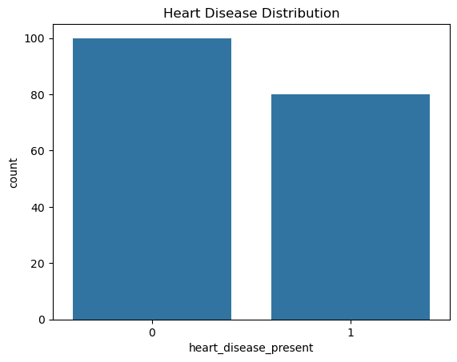

```python
sns.countplot(x='heart_disease_present', data=data1)
plt.title('Heart Disease Distribution')
plt.show()
```

**Insights**

The dataset shows a slight inbalance between two classes, where Class 0 (No Heart Disease) is the majority class, with a count of ~100 instances. And Class 1 (Heart Disease Present) is the minority class, with a count of ~80 instances.

The dataset is relatively balanced , though it leans slightly toward "No Heart Disease". While Class 0 is more frequent, the ratio (roughly 5:4) is not skewed enough to require aggressive resampling techniques.

**3.2 Numerical Feature Analysis**

**3.2.1 Age Distribution**

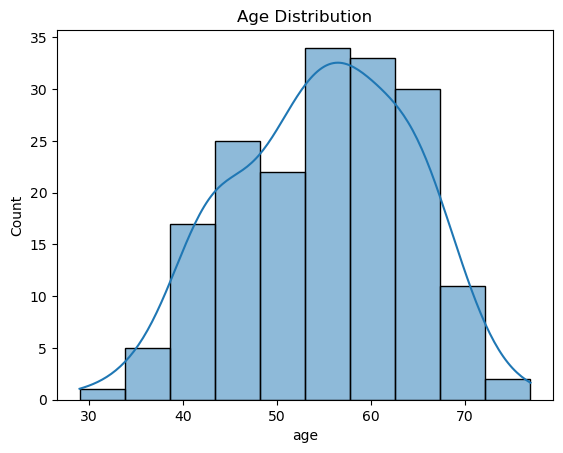

```python
sns.histplot(data1['age'], kde=True)
plt.title('Age Distribution')
plt.show()
```

**Insights**

The distribution is negatively skewed (left-skewed), meaning the "tail" extends toward the younger ages while the majority of the data points are concentrated on the higher end of the scale, i.e. individuals in the 55-65 age range.

**3.2.2 Gender Distribution**

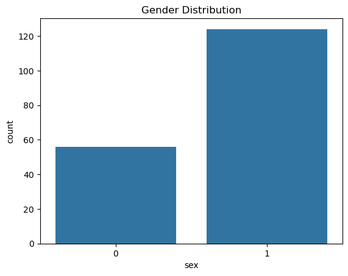

```python
sns.countplot(x='sex', data=data1)
plt.title('Gender Distribution')
plt.show()
```

**Insights**

**3.2.3 Gender vs Heart Disease**

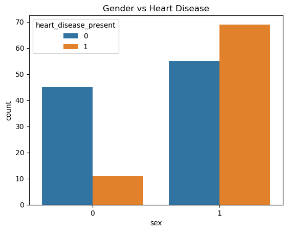

```python
sns.countplot(x='sex', hue='heart_disease_present', data=data1)
plt.title('Gender vs Heart Disease')
plt.show()
```

**Insights**

The dataset is imbalanced, it contains a larger overall sample of males than females.

The dataset shows Males (category 1) has a significantly higher incidence of heart disease (orange bars) compared to females (category 0). For females, the vast majority do not have heart disease, with the "no-disease" group (blue) being roughly four times larger than the disease" group. For males, the distribution is nearly 1:1, meaning a male in this dataset is much more likely to have a heart disease diagnosis than a female.

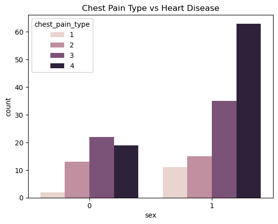

```python
sns.countplot(x='sex', hue='chest_pain_type', data=data1)
plt.title('Chest Pain Type vs Heart Disease')
plt.show()
```

**Insights**

The dataset is imbalanced. There is a clear imbalace between Group 0 and Group 1. Group 1 has much larger total count compared to Group 0. Within both groups, the distribution of chest pain types is not uniform. Types 3 and 4 dominate the count, while types 1 and 2 are underrepresented.

**3.2.5 Cholesterol Distribution**

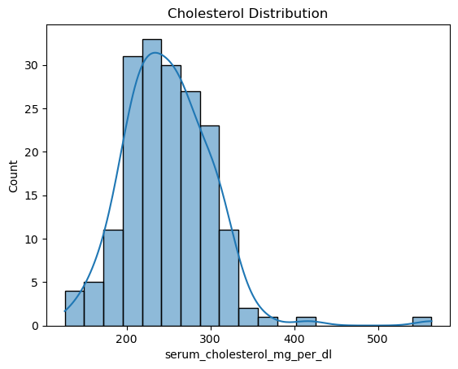

```python
sns.histplot(data['serum_cholesterol_mg_per_dl'], kde=True)
plt.title('Cholesterol Distribution')
plt.show()
```

**Insights**

The dataset Clearly shows inbalance in the feature values. The distribution is not perfectly symmetrical. There are very few data points for "normal" cholesterol (under 150 mg/dl) compared to the "high" categories. There are visible outliers on the far right (near 550 mg/dl). In this dataset, these individuals represents high-risk cases.

High serum cholesterol is a primary risk factor for heart disease. Because the bulk of the data sits above the "desirable" level (typically <200 mg/dl), this populaton appears to be at a significant cardiovascular risk. The majority of the sample falls between 200 and 300 mg/dl, which is the range often associated with "borderline high" to "high" cholesterol in clinical settings.

**3.2.6 Correlation Heatmap**

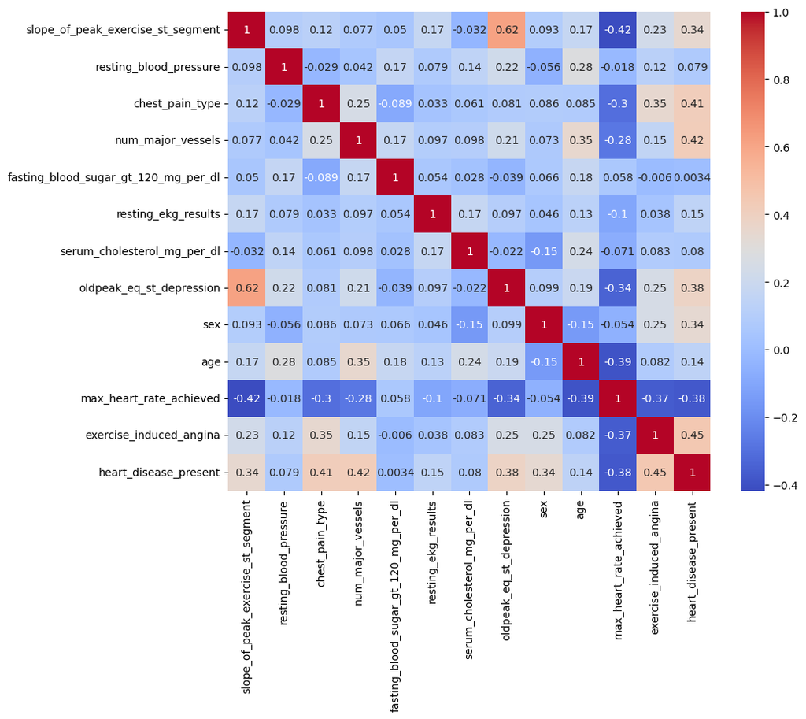

```python
plt.figure(figsize=(10,8))
sns.heatmap(data1.corr(numeric_only=True), annot=True, cmap='coolwarm')
plt.show()
```

**Insights**

This correlation heatmap illustrates the relationships between various clinical features and the presence of heart disease.

The dataset shows a notable correlation between oldpeak_eq_st_depression and slope_of_peak_exercise_st_segment (0.62). This is expected as both are indicators of cardiac stress during physical activity.

Age and max_hear_rate_achieved have a negative correlation (-0.39), reflecting the natural physiological decline of maximum heart rate as one ages.

**4. Data Cleaning and Preprocessing**

```python
# Identifying duplicate rows in the dataset
data1.duplicated()
```

```
0      False
1      False
2      False
3      False
4      False
       ...
175    False
176    False
177    False
178    False
179    False
Length: 180, dtype: bool
```

**Insights**

The output shows a Boolean Series where "False" indicates a unique row and "True" would indicate a duplicate. All visible rows (the first and last five) are unique.

```python
# Count missing values in a dataset
data1.isnull().sum()
```

```
patient_id                              0
slope_of_peak_exercise_st_segment       0
thal                                    0
resting_blood_pressure                  0
chest_pain_type                         0
num_major_vessels                       0
fasting_blood_sugar_gt_120_mg_per_dl    0
resting_ekg_results                     0
serum_cholesterol_mg_per_dl             0
oldpeak_eq_st_depression                0
sex                                     0
age                                     0
max_heart_rate_achieved                 0
exercise_induced_angina                 0
heart_disease_present                   0
dtype: int64
```

**Insights**

The output indicates that there are no missing values accross any of the features.

```python
# Encode categorical fields
from sklearn.preprocessing import LabelEncoder
le = LabelEncoder()
data1['thal']= le.fit_transform(data1['thal'])
```

```python
data1.head()
```

|  | patient_id | slope_of_peak_exercise_st_segment | thal | resting_blood_pressure | chest_pain_type | num_major_vessels | fasting_blood_sugar_gt_120_mg_per_dl | resting_ekg_results | serum_cholesterol_mg_per_dl | oldpeak_eq_st_depression | sex | age | max_heart_rate_achieved | exercise_induced_angina | heart_disease_present |
| --- | --- | --- | --- | --- | --- | --- | --- | --- | --- | --- | --- | --- | --- | --- | --- |
| 0 | 0z64un | 1 | 1 | 128 | 2 | 0 | 0 | 2 | 308 | 0.0 | 1 | 45 | 170 | 0 | 0 |
| 1 | ryoo3j | 2 | 1 | 110 | 3 | 0 | 0 | 0 | 214 | 1.6 | 0 | 54 | 158 | 0 | 0 |
| 2 | yt1s1x | 1 | 1 | 125 | 4 | 3 | 0 | 2 | 304 | 0.0 | 1 | 77 | 162 | 1 | 1 |
| 3 | l2xjde | 1 | 2 | 152 | 4 | 0 | 0 | 0 | 223 | 0.0 | 1 | 40 | 181 | 0 | 1 |
| 4 | oyt4ek | 3 | 2 | 178 | 1 | 0 | 0 | 2 | 270 | 4.2 | 1 | 59 | 145 | 0 | 0 |

**Insights**

Categorical variable 'thal' is converted into numerical variable using Label Encoding.

LabelEncoder was selected because it is categorical column and machine learning algorithms require numerical inputs. The categorical values were converted into numeric labels while preserving distinct categories. Also, Tree-based ensemble models (like Random Forests) process label-encoded values efficiently without forcing an artificial ordinal relationship to degrade tree splits.

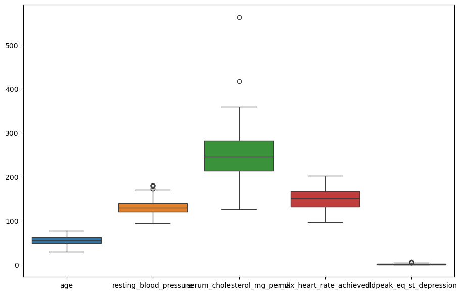

```python
# Checking for outliers
plt.figure(figsize=(11,7))
sns.boxplot(data=data1[['age', 'resting_blood_pressure', 'serum_cholesterol_mg_per_dl', 'max_heart_rate_achieved', 'oldpeak_eq_st_depression']])
plt.show()
```

**Insights**

The IQR method is used to identify and cap extreme values. This reduces the impact of unusal observations while preserving the overall data distributuion.

There is a significant difference in the scales of there variables (e.g., Cholesterol goes upto 400+, while ST Depression is near 0).

The Serum Cholesterol variable shows the highest values and the most significant spread. The presence of an outlier at the top end indicates some individuals have exceptionally high cholesterol levels compared to the rest of the group. The Resting Blood Pressure data is more tightly clustered than cholesterol. It also contains atleast one outlier on the higher end, suggesting a few instances of notably high blood pressure readings.

The Max Heart Rate variable appears relatrively normally distributed within its range, with a median that sits roughly in the center of its interquartile range. The Age range is fairly compact, primarily failing between 40 and 60 years old. The ST Depression value is very low and has extremely low variance, with most data points clustered near zero.

```python
# Function to Cap Outliers
def cap_outliers(column):
    Q1 = data1[column].quantile(0.25)
    Q3 = data1[column].quantile(0.75)
    IQR = Q3 - Q1
    lower = Q1 - 1.5 * IQR
    upper = Q3 + 1.5 * IQR
    data1[column] = np.where(data1[column] > upper, upper, data1[column])
    data1[column] = np.where(data1[column] < lower, lower, data1[column])

cap_outliers('serum_cholesterol_mg_per_dl')
```

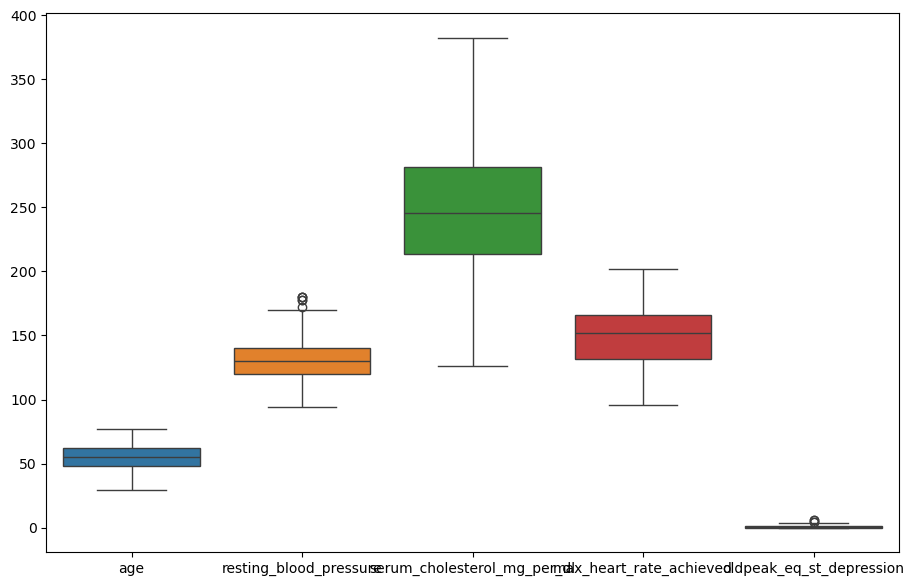

```python
plt.figure(figsize=(11,7))
sns.boxplot(data=data1[['age', 'resting_blood_pressure', 'serum_cholesterol_mg_per_dl', 'max_heart_rate_achieved', 'oldpeak_eq_st_depression']])
plt.show()
```

**Insights**

The dataset shows visible outliears in the resting_blood_pressure (high end) and peak_eq_st_depression (high end) categories. Serum cholesterol has the highest variance and the largest range, extending from ~120 to over 350. Most variables appear relatively symmetrical, though heart_rate_achieved suggests a slight left-skew.

Heart Rate Achieved has a fairly symmetrical distribution between 100 and 200. The Age median appears to be in the mid-50s, with most subjects falling between 45 and 65 years old. ST Depression variable has very low values (mostly near 0) with a significant outlier.

```python
# Splitting dataset
x = data1.drop(['patient_id', 'heart_disease_present'], axis=1)
y = data1['heart_disease_present']
```

**Insights**

The 'patient_id' column is removed from the feature set because it is a unique identifier. And it will not continue contributing to predict heart disease, as it could include introducing unnecessary noise into the model.

```python
# Train-Test Split
# Split the dataset into clean development and evaluating environments
from sklearn.model_selection import train_test_split
x_train, x_test, y_train, y_test = train_test_split(x, y, test_size=0.2, random_state=42)
```

**Insights**

The dataset is split into training and testing sets using a 20% test size, leaving 80% for training.

Features (x): All columns except heart_disease_present are retained to act as predictors.

Target (y): The heart_disease_present column is isolated as the label the model will attempt to predict.

```python
# Feature Scaling
from sklearn.preprocessing import StandardScaler
scaler = StandardScaler()
x_train_scaled=scaler.fit_transform(x_train)
x_test_scaled=scaler.transform(x_test)
```

**Insights**

Feature scaling is applied to standardize numerical variables and improve model performance. This prevents critical data leakage and maintains testing data integrity.

StandardScaler was chosen because Distance-based models (such as KNN and Logistic Regression) are sensistive to feature magnitudes and are heavily biased toward features with larger absolute ranges. Standardizing ensures all features contribute equally during model training.

```python
y.value_counts()
```

```
heart_disease_present
0    100
1     80
Name: count, dtype: int64
```

**Insights**

The target class is a highly balanced dataset, with a 55.6% to 44.4% distribution split. This do not need resampling model. Synthetic techniques like SMOTE is not required. Standard loss functions will perform well without modifications. Adjusting slgorithm class weights is not needed. The model will not inherently favor one class over another.

**TASK 1: DATA ANALYSIS REPORT (EDA)**

**Key Findings from EDA**

**Data Dimesions**

**Target column:** Heart Disease presence indicator

**Unique identifier:** patient_id column

**Outlier Detection**

**Visual method:** Boxplot boundary inspection

**Mathematical method:** Interquartile Range (IQR) filtering

**Univariate Exploration**

**Demographic Breakdown**

**Age distribution:** Concentrated primarily in mid-fifties range

**Gender representation:** Skewed heavily towards male records

**Class balance:** Even distribution of target variables

**Bivariate Analysis**

Low Max Heart Rate - Linked to Higher Disease Risk

High Oldpeak ST-Depression - Linked to Severe Tissue Stress

Reversible Thallium Defect - Linked to Structural Anomalies

**Statistical Distribution Insights**

**Max heart rate** decreases linearly as age increases

**Target Balance:** The target classes are relatively well-balanced. This eliminates severe class-imbalance bias.

**5. TASK 2: MACHINE LEARNING MODEL BUILDING AND EVALUATION**

We evaluate three distinct algorithms for clinical diagnostic for a heart disease.

```python
# Import Machine Learning libraries
from sklearn.linear_model import LogisticRegression
from sklearn.tree import DecisionTreeClassifier
from sklearn.ensemble import RandomForestClassifier
```

```python
# Import evaluating metrics
from sklearn.metrics import accuracy_score
from sklearn.metrics import confusion_matrix
from sklearn.metrics import classification_report
```

**5.1 Model 1: Logistic Regression**

```python
lr = LogisticRegression()
lr.fit(x_train_scaled, y_train)
y_pred_lr = lr.predict(x_test_scaled)
lr_acc = accuracy_score(y_test, y_pred_lr)
print("Logistic Regression Accuracy:", lr_acc)
```

```
Logistic Regression Accuracy: 0.8333333333333334
```

```python
# Classification report
print(classification_report(y_test, y_pred_lr))
```

```
              precision    recall  f1-score   support

           0       0.75      0.94      0.83        16
           1       0.94      0.75      0.83        20

    accuracy                           0.83        36
   macro avg       0.84      0.84      0.83        36
weighted avg       0.85      0.83      0.83        36
```

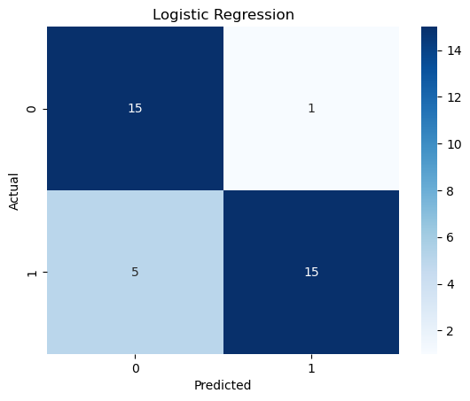

```python
# Confusion Matrix
cm = confusion_matrix(y_test, y_pred_lr)
sns.heatmap(cm, annot=True, fmt='d', cmap='Blues')
plt.title("Logistic Regression")
plt.xlabel("Predicted")
plt.ylabel("Actual")
plt.show()
```

**Insights**

The Logistic Regression confusion matrix shows an accuracy of 83.33%. It shows strong precision, meaning a positive heart disease diagnosis is highly reliable.

Both classes share an F1-score of 0.83, indicating a generally stable and balanced model across both categories.

The model has high Recall (0.94) means the model is very good at identifying Class 0, though it has some "false alarms" (lower precision of 0.75). Also, the model has high Precision (0.94) means that when the model predicts Class 1, it is almost always correct, but it misses about 25% of the actual Class 1 cases (lower recall os 0.75).

**5.2 Model 2: Decision Tree**

```python
dt = DecisionTreeClassifier(random_state=42)
dt.fit(x_train, y_train)
y_pred_dt = dt.predict(x_test)
dt_acc = accuracy_score(y_test, y_pred_dt)
print("Decision Tree Accuracy:", dt_acc)
```

```
Decision Tree Accuracy: 0.7777777777777778
```

```python
# Classification report
print(classification_report(y_test, y_pred_dt))
```

```
              precision    recall  f1-score   support

           0       0.67      1.00      0.80        16
           1       1.00      0.60      0.75        20

    accuracy                           0.78        36
   macro avg       0.83      0.80      0.78        36
weighted avg       0.85      0.78      0.77        36
```

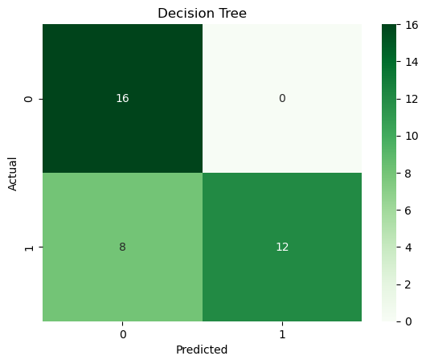

```python
# Confusion matrix
cm = confusion_matrix(y_test, y_pred_dt)
sns.heatmap(cm, annot=True, fmt='d', cmap='Greens')
plt.title("Decision Tree")
plt.xlabel("Predicted")
plt.ylabel("Actual")
plt.show()
```

**Insights**

Decision Tree confusion matrix shows an accuracy of 77.8%. The model shows a slight imbalance, but not enough to severely skew results.

The model is "cautious" about predicting Class 1. It has perfect Precision (1.00), meaning everytime it predicted Class 1, it was correct. The Recall is lower (0.60), suggesting it missed about 40% of the actual Class 1 instances (False Negatives).

The model is noticeably biased towards the Class 0. It has high Recall (1.00), meaning it successfully identified every actual instance of Class 0. However, its Precision is lower (0.67), indicating that when it predicts Class 0, it is only correct abour 67% of the time (likely due to some False Positives).

Both the macro avg (0.78) and weighted avg (0.77) for the F1-score are very close, indicating the model's performance is relatively stable across both classes.

**5.3 Model 3: Random Forest**

```python
rf = RandomForestClassifier(n_estimators=100, random_state=42)
rf.fit(x_train, y_train)
y_pred_rf = rf.predict(x_test)
rf_acc = accuracy_score(y_test, y_pred_rf)
print("Random Forest Accuracy:", rf_acc)
```

```
Random Forest Accuracy: 0.8055555555555556
```

```python
# Classification report
print(classification_report(y_test, y_pred_rf))
```

```
              precision    recall  f1-score   support

           0       0.71      0.94      0.81        16
           1       0.93      0.70      0.80        20

    accuracy                           0.81        36
   macro avg       0.82      0.82      0.81        36
weighted avg       0.84      0.81      0.80        36
```

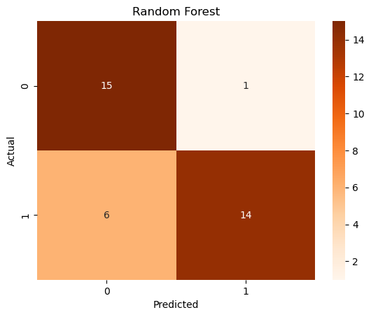

```python
# Confusion Matrix
cm = confusion_matrix(y_test, y_pred_rf)
sns.heatmap(cm, annot=True, fmt='d', cmap='Oranges')
plt.title("Random Forest")
plt.xlabel("Predicted")
plt.ylabel("Actual")
plt.show()
```

**Insights**

Random Forest confusion matrix shows an accuracy of ~80.6%. The dataset appears relatively balanced.

The Class O performance has high Recall (0.94), meaning the model is very good at identifying most of the actual positive instances of Class 0, though it has some "false alarms" (0.71 Precision).

The model is "conservative" when predicting Class 1. This class has high Precision (0.93), meaning when the model predicts Class 1, it is alomst always right. However, it misses about 30% of actual Class 1 cases (0.70 Recall).

The dataset is relatively balanced, making macro avg (0.81) a reliable metric for overall performance.

**6. Model Comparison Report**

**6.1 Performance Table**

```python
model_accuracy = pd.DataFrame({
    'Model':['Logistic Regression',
             'Decision Tree',
             'Random Forest'],
    'Accuracy': [lr_acc,
                 dt_acc,
                 rf_acc]})
model_accuracy
```

|  | Model | Accuracy |
| --- | --- | --- |
| 0 | Logistic Regression | 0.833333 |
| 1 | Decision Tree | 0.777778 |
| 2 | Random Forest | 0.805556 |

**6.2 Model Comparison Graph**

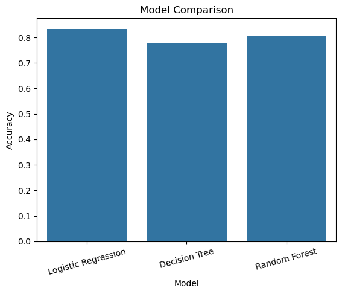

```python
# Accuracy visualization
sns.barplot(x='Model',
            y='Accuracy',
            data=model_accuracy)
plt.title("Model Comparison")
plt.xticks(rotation=15)
plt.show()
```

**6.3 Best Model Selection**

```python
best_model = model_accuracy.loc[model_accuracy['Accuracy'].idxmax()]
print(best_model)
```

```
Model       Logistic Regression
Accuracy               0.833333
Name: 0, dtype: object
```

```python
# Sample prediction
sample=x.iloc[[0]]
prediction=lr.predict(sample)
print("Predicted Class:", prediction[0])
```

```
Predicted Class: 1
```

**Insights**

The sample is selected using integer-based indexing, and uses a logistic regression model(lr) to classify the input sample. The output indicates that the model has categorized this specific sample into Class 1.

In binary classification for heart disease, this typically signifies a positive finding (e.g., presence of heart disease).

**7. Important Features Comparison**

```python
importance = pd.DataFrame({
    'Feature': x.columns,
    'Importance': rf.feature_importances_})
importance = importance.sort_values(
    by='Importance',
    ascending=False)
importance.head(10)
```

|  | Feature | Importance |
| --- | --- | --- |
| 3 | chest_pain_type | 0.124060 |
| 11 | max_heart_rate_achieved | 0.114330 |
| 1 | thal | 0.112389 |
| 8 | oldpeak_eq_st_depression | 0.112275 |
| 4 | num_major_vessels | 0.095126 |
| 10 | age | 0.092642 |
| 7 | serum_cholesterol_mg_per_dl | 0.080529 |
| 12 | exercise_induced_angina | 0.076493 |
| 2 | resting_blood_pressure | 0.066845 |
| 0 | slope_of_peak_exercise_st_segment | 0.054264 |

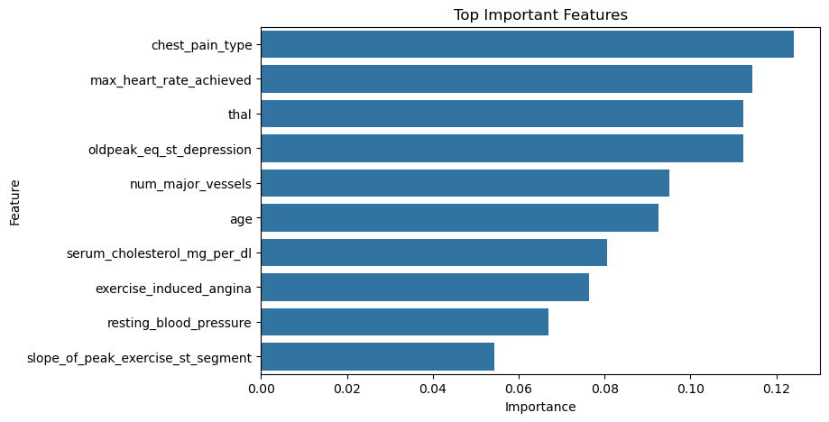

```python
top_features = importance.head(10)
plt.figure(figsize=(8,5))
sns.barplot(x='Importance',
            y='Feature',
            data=top_features)
plt.title("Top Important Features")
plt.show()
```

**TASK 2: PREDICTING MODEL STRATEGY**

**Selected Model: Logistic Regression** is suggested for Heart Disease Prediction.

For this specific dataset, a linear approach appears more effective or just as robust as complex ensemble methods like Random Forest. Random Forest serves as a strong backup or "challenger" model, as its performance is nearly identical to Logistic Regression.

**TASK 3: STRATEGIC RECOMMENDATIONS FOR HOSPITAL**

In corporate and clinical practice, predictive models must translate into actionable workflows. To maximize the patient safety and use these predictive assests effectively, hospitals should adopt the following procedures:

**1. Real-time Diagnostic Triggers:** Integrate the trained piple directly into the Electronic Health Records (EHR) framework to automatically lavel patients as high risk during routine checkups. When triage nurses input vitals and EKG readings, the model flags high-risk patients in real-time, escalating them for priority cardiac consultations.

**2. Targeted Early Screening:** Prioritize advanced cardiac imaging for individuals showing abnormalities in oldpeak_eq_st_depression or multiple blocked pathways in num_major_vessels . Use feature importance data to build early screening check-lists. Apply these simplified checklists during standard checkups for asymptomatic individuals over 50.

**3. Proactive Lifestyle Adjustments:** Automate wellness enrollments focusing on dietary sodium reduction and monitored exercises for male patients over 50 showing elevated resting_blood_pressure .

**4. Digital Health Alerts:** Implement a patient portal notification system. Group patients into Low, Moderate, and High-risk tiers based on the prediction probability output. If a patient's fasting clood sugar exceeds 120 mg/dl and they have high blood pressure, push atuomated preventative wellness advice. Patients flagged with high cardiovascular risk metrics - but who have not yet developed clinical disease - should be automatically enrolled in preventive care pathways (e.g., automated dietary tracking reminders, blood pressure checks, etc.).

**5. Staff Allocation Tuning:** Use model prediction trends to forecast higher cardiac admissions. Scale emergency room cardiology nursing staff accordingly during high-risk seasons.

**6. Automated EHR Screening Trigger:** Embed the finalized model directly into the Hospital's Electronic Health Record (EHR) ecosystem. When a practitioner enters basic blood work or vitals that surpass risk thresholds, the system flags the patient for an immediate cardiology consultation.

**REPORT ON CHALLENGES FACED AND MITIGATION TECHNIQUES**

**1. Data Leakage Risk Mitigation**

**Challenge:** Standardizing features using a global dataset mean and variance before splitting introduces lookahead bias, inflating performance metrics.

**Mitigation:** Implemented an **encapsulation** architecture to split dataset cleanly, computing descriptive properties only on training batches.

**Reason:** It is essential to provent any form of data leakage where information from the future (the test set) "leaks" into the training process. By standardizing features using only the training set's mean and variance - rather than the global dataset statistics - one ensures the model is evaluated on truly unseen data. This technique maintains the integrity of the performance metrics, providing a realtistic estimate of how the model will generalize to real-world, out-of-sample data.

**2. Feature Scale Variance**

**Challenge:** Features like serum_cholesterol_mg_per_dl and oldpeak_eq_st_depression operate on wildly different numeric ranges. Distance-based or regularized models could over-index on higher-valued matrics.

**Mitigation:** Incorporated **Standard Scaler** inside the numeric pipeline to normalize data mean to 0 and variance to 1.

**Reason:** Primarily, it is to ensure that machine learning models treat all features with equal importance, regardless of their original units or magnitude. By normalizing the data to a mean of 0 and a variance of 1, one prevents a specific feature from dominating the objective function and leading to faster convergence and more stable, accurate model performance.

**3. Categorical String Processing (thal)**

**Challenge:** The feature "thal" contains text labels (normal, fixed_defect, reversible_defect). Passing text directly into sklearn algorithms throws a value error.

**4. Imbalanced Categorical Representation**

**Challenge:** The "thal" feature contained uneven distributions of structural defects across demographics.

**5. Sensitivity to Outliers**

**Challenge:** Extreme values in serum_cholesterol_mg_per_dl (above 400 mg/dl) distorted early trial models.

**Reason:** It is used to handle extreme outliers in a dataset without losing valuable information. By restricting feature values to a consistent range, clipping helps stabilize the training process, reducing overfitting caused by a few rare, extreme values. In clinical trials, extreme values may be medically valid rather than errors. Clipping allows these cases to remain in the analysis while minimizing their potential to "distort early trial models".